# **Deterministic Two-Layer Interpretation of DNA** Position as Grammar, Quantity as Runtime — Framework, Multi-Organism Evidence, Form and Lifespan, *cis* Directly Measured from Sequence, an Early-Deve

### Figures of the simulation

The three figures below are the actual outputs of the runs described above (the files are in the bundle). Each caption restates what is shown and the honest limit.

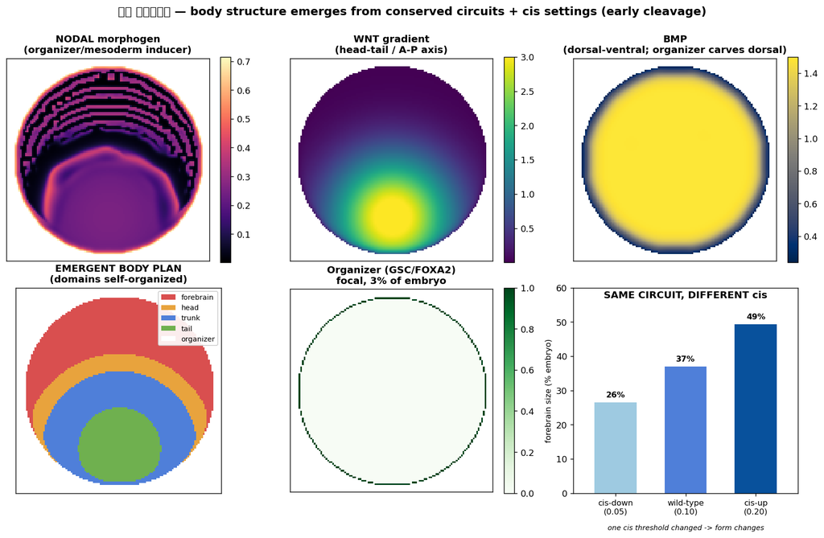

**Simulation v1 — structure self-organizes from conserved circuits and hand-set *cis* thresholds.** Top row: the morphogen fields NODAL, WNT (the head-tail gradient, bright at the posterior pole), and BMP. Bottom row: the emergent body plan (forebrain, head, trunk, tail, organizer self-organized from a single maternal asymmetry); the focal organizer ($\sim\!3\%$); and the core experiment — changing one *cis* threshold scales the forebrain ($26\%\!\to\!37\%\! \to\!49\%$) with the circuit untouched. Domains appear concentric because the embryo is a 2D cross-section; the real organizing axis is head-to-tail.

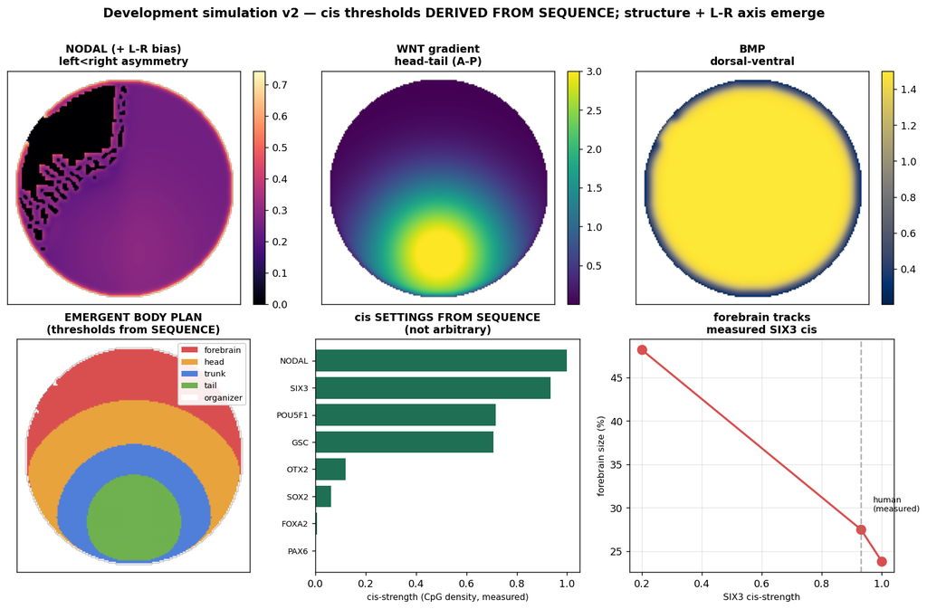

**Simulation v2 — *cis* thresholds derived from sequence, with a left-right axis.** NODAL now carries a left-right asymmetry (left dark, right bright); the WNT head-tail gradient and the emergent body plan are as before, but the thresholds are computed from each gene’s regulatory-landscape CpG density rather than hand-set. The lower-middle panel shows the sequence-derived *cis* settings; the lower-right panel shows the forebrain size tracking the *SIX3* *cis* value. (CpG density is a *proxy*; v3 replaces it with direct measurement.)

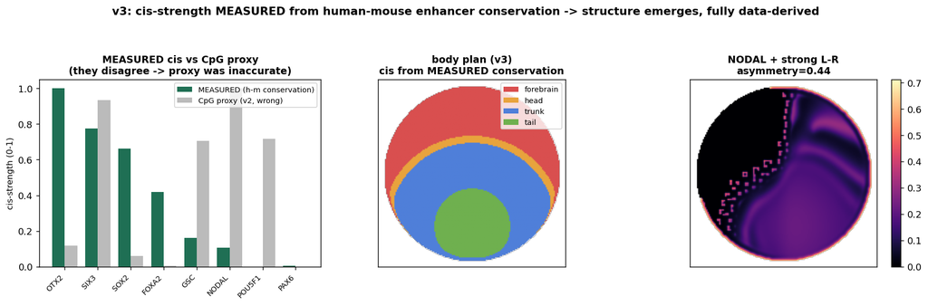

**Simulation v3 — *cis* from measured human–mouse enhancer conservation.** Left: the measured *cis*-strength (human–mouse conserved-enhancer signal) disagrees strongly with the CpG proxy of v2 — *OTX2* measures strong but is CpG-poor, *NODAL* the reverse — a concrete case of a plausible proxy being wrong. Middle: structure still self-organizes with the measured values. Right: NODAL with a strong left-right asymmetry ($0.44$). The organizer is small here ($\sim\!0.5\%$) because the measured *GSC* conservation is low in our window — an honest consequence of using the measured value.

### Version 7: making position run — form from *cis*, and why coordinates must be read from the genome

The simulation of Section 8.2 already shows the two conclusions it was built for: conserved reaction–diffusion circuits read by *cis* thresholds are *sufficient* to self-organize a body plan, and changing one *cis* setting changes the form. Version 7 extends it in two ways that turn the local/global principle of Section 12 into something you can *run*: it separates the form knob from the size knob explicitly, and it adds limb placement, which forces a lesson the head/trunk/tail readout could otherwise hide — that a body coordinate is not free to choose, but must be *read from the genome’s own position code*.

#### Limb placement forces the coordinate-reading lesson (a tetrapod extension)

The readout so far labels forebrain/head/trunk/tail from the anterior–posterior coordinate. A tetrapod also carries paired limbs at *specific* anterior–posterior positions, and how we obtain those positions is the whole point.

###### The wrong way, and what it produces.

If the limb anterior–posterior coordinates are *hand-set* — numbers we simply choose — the limb fields land at arbitrary places and the body is malformed: a forelimb and a hindlimb at positions with no relation to the axial plan. A deformity is the honest result of inventing a coordinate.

###### The right way: read the coordinate from the Hox arrangement.

The Hox cluster is colinear — genomic order tracks the head-to-tail axis (Section 1.1, and the fourth, temporal component of Section 5). So the limb coordinate is already written, as a *position* in the cluster. Reading the *HOXA* gene order, the forelimb field maps to the *Hox6* level (normalized anterior–posterior $\approx 0.52$) and the hindlimb to *Hox10* ($\approx 0.77$); placing each limb field where the embryo’s anterior–posterior readout equals its Hox-derived coordinate yields a correctly proportioned tetrapod.

```python
# ---- READ THE LOCAL COORDINATE FROM THE GENOME (Hox colinearity) ----
hox_order = gene_table.cluster_order('HOXA')       # 1D genomic order = A-P order
frac      = {g: rank(g, hox_order)/(len(hox_order)-1) for g in hox_order}
ap_fore   = frac[paralog_group(6)]     # forelimb  ~ Hox6   -> ~0.52
ap_hind   = frac[paralog_group(10)]    # hindlimb  ~ Hox10  -> ~0.77

# ---- PLACE LIMB FIELDS WHERE THE EMBRYO A-P READOUT MATCHES ----
wn = WNT / max(WNT on embryo)                       # normalized A-P coordinate (as before)
forelimb = limb_field_at(wn ~= ap_fore)             # not hand-set: read from frac{}
hindlimb = limb_field_at(wn ~= ap_hind)
# Hand-setting ap_fore/ap_hind to arbitrary numbers instead -> malformed body.
```

###### The lesson, and its honest boundary.

A body coordinate is a *local* coordinate (Section 3.5): it must be *read* from the genome’s position code — here the Hox arrangement — not invented. This is the constructive, runnable form of “position is encoded, and read.” Its boundary is exactly the local/global split: the genome cleanly gives *order* and *identity* (forelimb anterior to hindlimb; which paralog marks which limb), and that is what the simulation reads correctly; the *absolute metric* placement — how large, how far in real units — belongs to the growth/timing layer, i.e. to the *global* size parameter (Sections 12, 11), which this simulation does not set. So even in limb placement, *form (order/identity) is local and read from sequence*, while *size (absolute extent) is global and is not*. The honest limits of Section 8.8 carry over unchanged, with one addition: species-specific limb specializations (a bat’s wing proportions, an elephant’s trunk) are the variable layer, out of scope without species-specific regulatory data — like size itself.

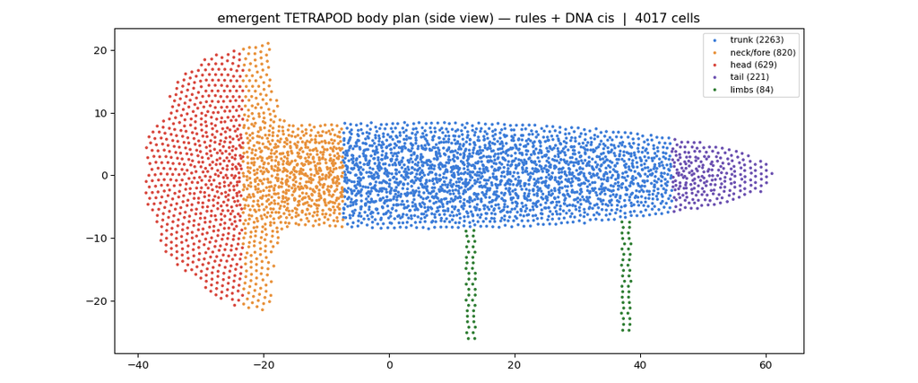

**A tetrapod body plan with limbs placed at Hox-derived coordinates.** The axial domains (forebrain/head/trunk/tail) are read from the anterior–posterior morphogen field as in the development-simulation listing; the paired limbs are placed at the normalized coordinates *read* from the *HOXA* colinear order (forelimb $\approx$ Hox6 $\approx 0.52$; hindlimb $\approx$ Hox10 $\approx 0.77$). Hand-setting these coordinates instead produces a malformed body; reading them from the Hox arrangement does not. Code: `dna_to_animal.py`; the Hox$\to$A-P table in `hox_ap.json`.

### Where the size difference is stored: runtime and growth *cis*

#### A puzzle the paired run raised

The human-versus-mouse paired run (Section 8.7) produced nearly identical body plans because the measured *early* *cis* of the two species is nearly identical. But a human and a mouse differ enormously in size. If the difference is not in the early *cis*, where is it? The answer follows from a simple, correct observation: *early embryos are similar in size*; the size difference between a human and a mouse appears *later*, during gestation and growth. So the difference cannot be stored in the early organizer *cis* we measured. It must be stored in two other places — and our framework names both.

#### Two stores, neither of them early *cis*

- **Store 1 — the runtime (duration).** How *long* an animal gestates and grows is a Layer-2 quantity: human gestation is about $280$ days, mouse about $20$; time to maturity differs likewise. The genome supplies the growth *machinery*; the runtime sets the *duration* for which it runs. This is exactly the two-layer asymmetry — the genome encodes the machine, the cell sets “how much / how long.” Honestly marked: gestation and growth period are off-genome quantities, so this store is *literature*, not something we measure from sequence.
- **Store 2 — the growth *cis* (late in the cascade).** The growth circuit — *IGF1*, *IGF2*, *HMGA2*, the growth-hormone axis — acts during the *growth* phase, not at gastrulation. Its enhancers are *cis*, written in the sequence, but they sit *late* in the developmental cascade. By the depth law of Section 3.5, a late *cis* element is *less* deeply fixed than an early one, and so should be *more* divergent between species. If that is true, the growth *cis* is exactly where the size difference is stored — and unlike the runtime, this store we *can* measure.

#### The prediction, and its direct test

The depth law makes a sharp, falsifiable prediction. We measured the *early* organizer *cis* and found it strongly conserved between human and mouse. If the depth law is right, the *growth* *cis* (IGF1, IGF2, HMGA2) should be measurably *less* conserved between the same two species. We obtained the human and mouse sequence for the three growth loci ($\sim\!320$– $440$ kilobases each) and measured their human–mouse enhancer conservation by exactly the method used for the early loci (conserved-enhancer signal = summed peak shared-$15$-mer windows; and, as an independent check, the overall shared-$15$-mer fraction of the locus).

#### What this establishes

This is a clean confirmation of the user-anticipated picture and of the depth law at once. The reasoning chain closes:

- Early embryos are similar in size, so the size difference is not set early.
- The early organizer *cis* is strongly conserved between human and mouse (measured), so it does not store the difference — consistent with the paired run building nearly identical plans.
- The growth *cis* (IGF1/IGF2/HMGA2) is $8.3\times$ *less* conserved human–mouse (measured), so it is the *least-constrained* layer — consistent with the depth law’s prediction that the late layer diverges most. We are careful about what this does and does not show: “least conserved” is not the same as “stores the value.” A direct test on the $48\times$ human–elephant pair (Section 11.5) finds the non-imprinted growth *cis* (*IGF1*, *HMGA2*) at the unrelated-sequence *noise floor*, so the size magnitude is *not* recoverable as a conserved *cis* element there. The honest reading is that the growth *cis* is the most divergent layer, not a sequence store of the magnitude.
- The remaining part of the difference — *how long* the growth circuit runs — is the runtime (gestation and growth duration), a Layer-2 quantity off the genome.

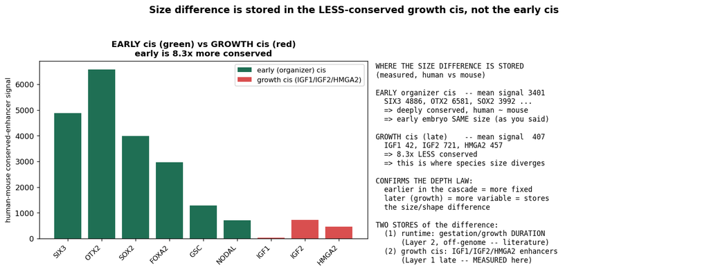

**The size difference is stored in the less-conserved growth *cis*, not the early *cis*.** Left: human–mouse conserved-enhancer signal for the early organizer loci (green) and the growth loci (red); the early *cis* is $8.3\times$ more conserved. Right: the reasoning — early *cis* is deeply conserved (so early embryos and early plans are alike), the growth *cis* is the most divergent layer (depth law); the remaining variation is runtime (gestation and growth duration, Layer 2, off-genome). A direct $48\times$ test (Section 11.5) shows this divergence reaches the conservation noise floor, so the growth *cis* is the *least-constrained* layer, not a recoverable store of the magnitude. Code: `growth_vs_early_cis.py` (the measurement) in the bundle.

This result also strengthens, with a second independent measurement, the depth law registered as Hypothesis H-cis3: the earlier a *cis* element acts, the more deeply it is fixed. We now have it both ways — the early loci measure as highly conserved, and the growth loci, acting later, measure as markedly less conserved, by the same method on the same species pair.

#### Where body size lives: an open question, stated honestly

We pursued the body-size question further than any single locus, and the honest summary is that we found *no decisive single store*. Several factors were examined and each contributes a little; none dominates. (i) Per-locus *cis*: the 4D interpretation of growth and skeletal receptor loci (*IGF1*, *FGFR3*, *NPR2*, *SOX9*, *RUNX2*, *IHH*, *PTHLH*) finds the *house* (shell/anchor architecture) largely shared between species of vastly different size; the magnitude is not localized there. (ii) Cell size is conserved across mammals (mouse to elephant), so body mass is carried by cell *number*, not cell size. (iii) Cell number is the product of division rate and growth duration; in the mouse–human comparison this maps onto species-specific developmental tempo (a runtime/biochemical quantity, e.g. protein-stability differences), not onto a sequence store — for the elephant, only the duration (gestation) is directly measured, the tempo inferred. (iv) Within a species, human-height GWAS distributes the trait across hundreds of loci, each contributing slightly, jointly explaining only a fraction of heritability; the remainder is non-shared/regulatory. (v) A test for height-variant enrichment in 4D stiffness anchors/soft shells at *IGF1* was *negative* — functional regulatory position (open chromatin, TF sites) is not predicted by stiffness geometry, marking a real limit of the method.

We also checked the *global* genome, not only single windows: across whole genomes from choanoflagellates and colonial algae to early animals, the global soft-shell fraction and its clustering did *not* differ with multicellular grade. So size is not visibly stored globally either, by this measure.

###### Open items (Version 7).

Three concrete next steps are recorded so others can extend this (the method is meant to be added to, not closed). *(i) A functional instrument for the value.* Reading the size *value* — not just where it is and is not — needs expression, hormone-output, or methylation data, or many-individual (GWAS-scale) association; single-locus sequence comparison is now exhausted. *(ii) Complete the felid let-7 control.* Tiger *HMGA2* is unannotated in the current assembly (only *HMGA1* is placed); a synteny-guided tiger *HMGA2* $3'$UTR region would close the within-family let-7 test of Section 11.8. *(iii) Read more axes of position.* The form work reads the anterior–posterior (Hox) axis; reading the proximal–distal (*ZRS*/*SHH*) and dorsoventral (*Dlx*/*Tbx*/*Wnt*) coordinates from the genome would extend Section 10 beyond one cluster — “read the whole position code, not a single map.” All inputs to be recorded as public accessions/ranges in `DATA_LOCK` (never raw genomes; the 250 MB ceiling holds).

#### Version 7: a lineage-controlled test — the regulatory-density “size signal” is lineage, not size

The open question above is honest but improvable. Version 6 marked that “a global, multi-locus analysis we did not perform could revise it,” and it stated the governing discipline for any cross-species size claim: *compare only within a family, never as a gradient of descent*. Version 7 executes exactly that discipline with two new tests. Both *sharpen* the distributed-size conclusion by removing a tempting local store; neither overturns it.

###### Test A — dosage across $\sim\!8000\times$ body mass.

We counted the copy number of the growth/hormone/appetite circuit (the accelerators and brakes of Section 2, plus the central appetite controllers *MC4R*, *MC3R*, *LEPR*, *POMC*, *NPY*, *CARTPT*, *PCSK1*, *BDNF*, *SIM1*, and the adapters *IRS1/2/4*) in four annotated genomes ordered by body mass — mouse ($0.025$ kg), cat ($4$ kg), human ($62$ kg), tiger ($200$ kg). *Algorithm (in words).* For each genome’s GFF, count `gene` features per symbol; for a gene family, count members by name prefix (`GH`$\backslash$`d`/`CSH`, `PRL`, `IGFBP`, `SSTR`); align the count vector to body mass; a feature “tracks size” only if its count is monotone in mass *and* the change exceeds one copy.

```python
MASS = {mouse:0.025, cat:4, human:62, tiger:200}          # kg
SINGLE   = [GHR, IGF1, IGF2, IGF1R, IGF2R, INSR, PRLR, SST,
            MC4R, MC3R, LEPR, POMC, NPY, CARTPT, PCSK1, BDNF, SIM1, IRS1, IRS2, IRS4]
FAMILIES = {PRL: '^PRL', GH_CSH: '^(GH#|CSH)', IGFBP: '^IGFBP#', SSTR: '^SSTR#'}

def counts(gff):                          # one pass over the GFF
    for line in gff where feature == 'gene':
        name = attribute 'Name' or 'gene'
        if name in SINGLE:           single[name] += 1
        for fam, pattern in FAMILIES:
            if name matches pattern: fam_set[fam].add(name)
    return single, {fam: size(fam_set[fam])}

for gene in SINGLE:                        # species ordered small -> big mass
    row   = [count[sp][gene] for sp in sort_by(MASS)]
    label = 'SIZE-TRACKING' if (row is ascending and row[-1]-row[0] > 1) else 'flat'
# RESULT: every SINGLE gene -> flat (1:1:1:1) across ~8000x mass. Only PRL (~29 in mouse)
#         and GH/CSH (5 in human) vary -> a LINEAGE (placental) expansion, not a size signal.
```

(An intra-development correction is kept visible: an equal-length Hamming comparison initially made *GDF15* and *IRS4* look divergent; a proper global alignment shows them conserved ($96.4\%$, $97.1\%$). The artifact was the equal-length method, not the biology.)

###### Test B — the decisive within-family control.

We measured regulatory-element density — CpG-island count per $100$ kb, the same kind of A4 feature used in the telomerase test of Section 3.4 — at the five growth-plate *skeletal-effector* loci (*IHH*, *NPR2*, *FGFR3*, *PTHLH*, *SOX9*), the genes where bone length, and therefore body size, is physically set. *Algorithm (in words).* Slide a $1$ kb window by $500$ bp; call a window a CpG island when its GC fraction exceeds $0.50$ and its observed/expected CpG ratio exceeds $0.60$; report islands per $100$ kb for each locus; take the big/small ratio per locus; *require replication in an independent family before calling a size signal*.

```python
def cpg_islands_per_100kb(seq, win=1000, step=500):        # O(n) via prefix sums
    cC, cG, cCG, cGC = cumsum(C), cumsum(G), cumsum(CpG), cumsum(G or C)
    islands = 0
    for s in range(0, len(seq)-win+1, step):
        e   = s + win
        gc  = (cGC[e]-cGC[s]) / win
        c,g = cC[e]-cC[s], cG[e]-cG[s]
        oe  = (cCG[e]-cCG[s]) * win / max(1, c*g)          # observed/expected CpG
        if gc > 0.50 and oe > 0.60: islands += 1
    return islands / (len(seq)/1e5)

GROWTH_PLATE = [IHH, NPR2, FGFR3, PTHLH, SOX9]             # bone-length effectors
for gene in GROWTH_PLATE:
    small, big = order_by_mass(species_for(gene))
    signal     = density[big] > density[small]             # does the big animal have more islands?
# CROSS-LINEAGE (mouse 0.025kg vs elephant 3t):  big>small at 5/5   (looks like a size code)
# WITHIN-FAMILY  (cat 4kg     vs tiger 200kg):    big>small at 1/5   (ratios ~0.83,0.63,1,1,0.95)
# -> the 5/5 was LINEAGE, not size. Admit a size signal only if it REPLICATES within a family.
```

This is the lineage-controlled test Version 6 called for and did not have. Its result is a clean *negative*: it removes a tempting local store and leaves the distributed/global reading standing.

#### Version 7: a stop-coordinate test — the let-7/*HMGA2* growth brake is conserved

A different and sharper challenge reframes size not as a stored magnitude but as a *stop coordinate*: perhaps growth simply runs until a genomically written brake fires, and the brake’s position is the size. The strongest molecular candidate is the let-7/*HMGA2* axis: *HMGA2* is the single strongest body-size/height locus known, and the microRNA let-7 represses *HMGA2* to terminate growth. The number of let-7 target sites in the *HMGA2* $3'$UTR is the brake’s strength — a specific sequence coordinate one can count, not a distributed quantity. *Algorithm (in words).* A let-7 family site is the $7$-mer seed match `CTACCTC` (and the $1$A variant `TACCTCA`) on the mRNA sense strand (its reverse complement on the antisense strand for a genomic region); count the matches in the densest $4$ kb window of the $3'$UTR. The method was validated on the human *HMGA2* $3'$UTR, which returns the textbook $\sim\!8$ sites.

```python
SEEDS = ['CTACCTC', 'TACCTCA']          # let-7 7-mer seed + 1A variant (mRNA sense strand)

def let7_sites(utr, genomic=False, win=4000):
    patterns = SEEDS + (reverse_complement(SEEDS) if genomic else [])
    hits = [i for i in positions(utr) if utr[i:i+7] in patterns]
    return max over h in hits of count(x in hits : h <= x < h+win)    # densest 4 kb window

# validated on the human HMGA2 3'UTR -> ~8 (textbook).
# RESULT: human 8, elephant 8, cat 8 ; mouse 10 (rodent lineage).
# the brake COUNT is conserved across 1000x mass -> the size difference is in WHEN it fires
# (timing, a runtime quantity), not in the number of sites.
# (cat predicted model was 3'UTR-truncated and excluded; count recovered from the genomic 3'UTR.)
```

Like Test B, this is a lineage-controlled negative: the “grow until a coordinate” reframing is attractive, but the coordinate it points to is conserved, so it does not store the magnitude either. Together, Sections 11.7–11.8 convert Version 6’s open question into a *strengthened* one: two further tempting local stores (regulatory density; the developmental brake) are removed under proper controls, and the value continues to behave as a global, multi-locus parameter — in the genome, but not localizable — whose actual setting is read only from the functional/runtime layer (Section 12).

### Version 7: the 4D plan — form is a local arrangement, size is a global parameter

Three results in this paper have, until now, stood beside one another without a single statement that binds them: (a) the order of the letters *is* a local three-dimensional coordinate on the helix (Section 3.5); (b) a *cis* setting is read through a four-dimensional arrangement whose fourth axis is developmental time (Section 5), of which the colinear Hox cluster is the body-scale instance; and (c) the size value is not at any one place — it behaves as a sum over loci and over runtime (Section 11), a conclusion the Version-7 lineage-controlled tests (Sections 11.7–11.8) strengthen by removing two tempting local stores. Version 7 states the principle that unifies them.

###### The principle.

The genome’s design is *four-dimensional* in the plainest sense: it specifies a *local three-dimensional arrangement at each developmental stage*, and the stages are unrolled in time. From this one statement follows the asymmetry that has organized the whole paper, now in its sharpest form:

- **Form/position is *local*.** It is read off the arrangement *at a place* — which shell, which anchor, which fractional coordinate, which firing order. You can point to it. The helix coordinate, the A4 anchors, and the Hox map are all instances, and the form-from-*cis* simulation of Section 10 reads exactly these local coordinates to build a body.
- **Size/quantity is *global*.** It is a parameter of the *whole* trajectory — rate $\times$ duration, summed over thousands of small per-locus settings. It is not localizable to any single element. This is precisely why every *local* probe in the size investigation came back conserved: dosage across $8000\times$ mass, regulatory density under a within-family control, and the let-7 stop-coordinate are all flat or lineage-driven, because *size is not a local thing to find*. To read it one must read the whole — the runtime, or many loci jointly.

###### Scale-invariance.

The same local/global split holds at every scale, which is why the framework’s molecular and organismal claims rhyme. At the molecule, a condensate’s interface *position* is local (set by the sequence, $\gamma$) while its *fill* is a global, runtime quantity ($\phi$, Section 4.1); at the organism, a limb’s *position* is local (read from the Hox arrangement) while *body size* is global. The principle does not change with scale; only the parts it names do.

###### Distinction from the four-dimensional *decomposition*.

Section 5 decomposes a single *cis* setting into four arrangement-readable components (host, linkage block, anchor position, firing order) — it is the *reading method* for a local element. The present principle is the higher-level statement of which that decomposition is one application: the decomposition reads a *local* coordinate; the principle says *which traits are local at all*, and which are global and therefore unreadable from any single coordinate.

### Version 7: making the switch run — the condensate and response switches

Section 4.1 gave the two knobs ($\gamma$, $\phi$) and the capacity identity $N\,v_{\mathrm{eff}}\approx\phi\,V_{\mathrm{core}}$, but left the *switch* — what happens as a domain crosses capacity — as a statement rather than a runnable object. Version 7 makes it a deterministic, reproducible model, because the switch is the mechanism that explains how a *small, distributed (global)* change in setting can produce a *large, discrete* outcome — the sharpness behind both body-size differences and obesity.

###### Model 1 — the condensate switch.

Read the firm interface as a two-state order parameter $s$ in a double-well free energy
$$F(s;h)\;=\;\tfrac14 s^4 \;-\; \tfrac12\,\gamma\,s^2 \;-\; h\,s, \qquad h=h(\phi)=k\,(\phi-\phi_c),$$
where $\gamma$ (sequence-set, Layer 1) fixes the barrier — the *threshold* — and $\phi$ (runtime, Layer 2) tilts the wells. *Algorithm (in words).* Relax $s$ by gradient descent $\dot s=-\partial F/\partial s=-(s^3-\gamma s-h)$ to the nearest stable state; sweep $\phi$ upward and then downward, each time starting from the previous state, so the tracked state reveals both *bistability* and *hysteresis*. *Result.* The state flips almost vertically as $\phi$ crosses the $\gamma$-set threshold (maximum sensitivity $\mathrm{d}s/\mathrm{d}\phi\approx 438$ in the locked run) and the up- and down-sweeps differ (a hysteresis loop): two cells — or two animals — with the *same* $\gamma$ and only a small difference in $\phi$ can occupy *opposite* states (lean/obese, small/large). Code: `stiffness_switch.py`.

```python
# F(s; h) = s^4/4 - gamma*s^2/2 - h*s        (h = tilt set by fill phi)
dF(s, h, gamma) = s**3 - gamma*s - h
h(phi)          = k * (phi - phi_c)           # fill phi -> tilt of the two wells

def track(phis, gamma, s_start):              # gradient descent, CARRY state -> hysteresis
    s = s_start
    for phi in phis:
        repeat 2000x: s -= 0.05 * dF(s, h(phi), gamma)    # relax to nearest stable well
        record s
    return states

up   = track(phis_increasing, gamma, s_start=-1.2)
down = track(phis_decreasing, gamma, s_start=+1.2)
# RESULT: state flips almost vertically as phi crosses the gamma-set threshold
#         (max ds/dphi ~ 438); up-sweep != down-sweep (hysteresis).
#         SAME gamma (conserved machine) + a small d.phi near the boundary -> OPPOSITE states.
```

###### Model 2 — the response switch (the cell that receives the hormone).

The concrete biology behind the abstract switch is the cell-cycle restriction point: the Rb–E2F system is a known bistable, hysteretic switch. The input is the hormone/mitogen level the cell receives (the response-side $\phi$); the conserved switch hardware (the $\gamma$ side) reads it and commits to divide sharply. *Algorithm (in words).* Integrate a positive-feedback rate law $\dot E = b + k_1\,S/(K_m+S) + g\,E^{n}/(K_d^{n}+E^{n}) - d\,E$ to its stable fixed point; sweep the input $S$ up and down for hysteresis; vary the feedback gain $g$ (the response *sensitivity*, a setting) and watch the commit threshold move. *Result.* A more sensitive cell commits to divide at a *lower* hormone level, so it divides more and the tissue grows larger — the response *setting* (not the hardware) sets the size outcome. Code: `response_switch.py`.

```python
def steady_E2F(S, gain, n=4, Kd=1, d=1, b=0.02, k1=1, Km=1):
    # dE/dt = b + k1*S/(Km+S) + gain*E^n/(Kd^n + E^n) - d*E   (positive feedback -> bistable)
    E = 0
    repeat 4000x: E = max(0, E + 0.02*(b + k1*S/(Km+S) + gain*E**n/(Kd**n + E**n) - d*E))
    return E

up   = sweep(S_increasing, gain=1.6, start=0)        # sharp COMMIT-to-divide
down = sweep(S_decreasing, gain=1.6, start=high)     # hysteresis (bistable)
for gain in [low, mid, high]:
    curve = [steady_E2F(S, gain) for S in S_range]
# RESULT: higher sensitivity (gain) -> commits to divide at a LOWER hormone level
#         -> more divisions -> bigger tissue. The SETTING, not the hardware, sets the size outcome.
```

### Two worked examples, step by step

Part II gave a worked example — the neighbourhood of the *E. coli* replication origin — so that a reader could follow the framework’s pipeline by hand. In the same spirit, and because this Part rests on measurements a reader will rightly want to reproduce, we walk through the two central *cis* measurements end to end. Each is written so that someone new to the framework can repeat it from the public assemblies with the scripts in the bundle.

#### Worked example 1: reading the snake’s limb enhancer (ZRS)

###### The question.

Did the limbless python delete its limb enhancer, or merely turn it down? This is a question about a *cis* setting, and it is answerable by comparing sequences.

###### Step 1 — locate the locus from coordinates we already have.

From the human gene table, *SHH* sits on chromosome 7 at $155{,}799{,}980$–$155{,}812{,}463$, and *LMBR1* — the gene whose intron *hosts* the ZRS — at $156{,}669{,}012$–$156{,}893{,}183$. The ZRS is therefore expected near the *SHH*-distal end of *LMBR1*, about one million bases from *SHH*. We request the whole span as one region: `NC_000007.14:155799980–156893183`.

###### Step 2 — obtain the sequence as a region, not a genome.

Through the NCBI Genome Data Viewer we download the FASTA for exactly that range. It is $1{,}093{,}204$ bases — about one megabyte of text, not the multi-gigabyte whole chromosome — which is why the reproducibility bundle stays small. We do the same for the python, whose assembly is scaffold-level: *LMBR1* sits on scaffold `NW_006534369.1`, so we take `NW_006534369.1:1–150000`.

###### Step 3 — find the ZRS window in the human locus.

The region begins at genomic coordinate $155{,}799{,}980$, so a feature at genomic position $p$ sits at offset $p-155{,}799{,}980$ in our file. The ZRS lies at roughly $156{,}790{,}500$–$156{,}791{,}800$, i.e. offset $\approx\!990{,}520$–$991{,}820$. We cut that $1{,}300$-base window as the human ZRS.

###### Step 5 — read the result.

The ZRS window shares $112$ exact $15$-mers with the python; the *LMBR1* promoter shares $7$; the random intron shares $1$; the *SHH* exon shares $0$. The ZRS signal stands $112$-fold above the random-intron control. *The snake keeps a recognizable ZRS.* The tidy “the enhancer was deleted” story is false for this animal.

###### Step 6 — look inside the enhancer.

Mapping which bases of the human ZRS are covered by shared $15$-mers, $18\%$ of the $1{,}300$-base window is conserved — a conservative floor, since an exact $15$-mer is broken by even one substitution (a local alignment of the same windows scores about $77\%$ identity). The conserved material clusters in a core (longest conserved blocks $\sim\!58$, $\sim\!38$, $\sim\!29$ bases); the long diverged stretches lie in the flanks. The reading is *conserved core, diverged flanks* — a retained enhancer that has been tuned, not a deleted one.

###### What we may conclude, and what we may not.

We may conclude that the python retains a conserved ZRS core, which refutes deletion and is consistent with the vestigial pelvic spurs pythons still grow. We may *not* conclude, from sequence alone, exactly how much the enhancer’s activity is reduced; conservation constrains activity but is not a direct assay of it. That is the honest edge of the measurement, and we mark it.

#### Worked example 2: measuring an early-development *cis* setting (*SIX3*)

###### The question.

The earliest forebrain master is *SIX3*. Human and mouse have very different head shapes. Is that difference carried by the *presence or absence* of *SIX3*’s enhancers, or by fine tuning within enhancers that both species share?

###### Step 1 — obtain matched regions in two species.

From the gene tables we find *SIX3* and take $\sim\!300$ kilobases around it in each species, enough to include the distal enhancers that sit far from the gene: human `NC_000002.12:44791702–45096071` and mouse `NC_000083.7:85771036–86083619`. Each is about a third of a megabyte of text.

###### Step 2 — scan the human locus in windows.

We slide a $500$-base window along the human locus in $100$-base steps. For each window we count the exact $15$-mers it shares with the *entire* mouse locus. A window that shares many $15$-mers is a stretch of sequence conserved between the two species — a conserved non-coding element, i.e. an enhancer (or the gene itself).

###### Step 3 — separate the gene from its enhancers.

The *SIX3* coding body occupies only about $4$ kilobases (offset $\approx\!150{,}000$–$154{,}369$ in our window). We exclude it, so that what remains is the *regulatory landscape* — the conserved non-coding blocks, which are the enhancers.

Between two species of markedly different head and brain proportion, the forebrain enhancers are conserved *in existence*. So the species-distinguishing difference is not the gain or loss of these enhancers; it is fine tuning *within* them — the same reading the ZRS forced for the limb, now at the top of the cascade. The scope is honest: we measured conservation (the existence and rough strength of each enhancer) between *two* species, not the precise activity difference between the human and mouse versions, and not a panel of many species.

###### Why this matters for the whole paper.

These two examples are the method behind every *cis* number in Part VI. The per-locus *cis*-strengths of Section 6.5, the proxy-disagreement result, and the thresholds that drive the version-3 simulation are all produced by exactly this procedure: take matched regions, count exact shared words in sliding windows, separate gene from landscape, and read the conserved enhancers. It uses no alignment heuristics and no tunable scores, so it is deterministic and a reader can reproduce every figure to the digit.